# Chaos in the EGX30? A replication of Morad, Rady & Amin (2019)

Replication, referee-requested revisions, and a validated chaos toolkit

Published

September 26, 2026

# Summary of findings

**Bottom line.** The EGX30 data reproduce the paper’s descriptive results closely. Every test that can separate chaos from noise, once validated, **rejects low-dimensional chaos**. The nonlinearity the paper found is volatility clustering plus regime shifts in volatility. The long-memory and 1,240-day-cycle claims do not survive bias correction and correct critical values. This supports the referee’s recommendation to recast the paper as a study of nonlinearity and weak-form efficiency.

**Validation (Section 2) shows which tools can be trusted.**

- **DChaos λ̂ discriminates.** It recovers λ = 0.693 on the logistic map (λ̂ = 0.678). It stays positive and non-rejected with measurement noise, and is significantly negative for GARCH, IID and fGn. In the Monte Carlo it calls chaos in 0% of GARCH and IID replications and 100% of noisy-logistic ones.
- **DChaos fails on the periodic map.** On the period-4 map (r = 3.5) it reports λ̂ = 0.260 without rejecting chaos. The neural-net estimator breaks down on a degenerate 4-point orbit, so λ̂ is never read alone. The 0–1 test gets that case right (K ≈ 0).
- **Nearest-neighbour forecasts discriminate.** They beat the mean forecast only for deterministic data.
- **The 0–1 test cannot tell noise from chaos.** It gives K ≈ 1 for GARCH and IID noise in 100% of replications. It only separates regular from irregular dynamics, so K ≈ 1 on EGX30 is uninformative.
- **Raw BDS cannot tell GARCH from chaos.** It rejects IID in 100% of GARCH replications and in 0% once GARCH-filtered.
- **AMI does not pick the right delay for maps.** It picks τ = 3–7 for the logistic map, whose delay is 1, so all embeddings use τ = 1.
- **Classical R/S is biased upward.** It gives H ≈ 0.55 on IID noise; the Anis–Lloyd–Peters correction brings it to 0.49.

**Replication, paper window 2000–2015.**

- **Table 1.** Mean, sd, skewness, kurtosis and IQR match the paper to two or three significant digits. The file lacks 1998–1999, so N = 3,894 rather than 4,393.
- **Table 2.** ADF and PP statistics match in sign and scale. BIC selects AR(1) and AIC selects AR(10); AR(2) residuals fail Ljung–Box.
- **Table 3 (referee M3 confirmed).** The paper’s variance ratios are those of the *differenced* returns: 0.603, 0.300, 0.156, 0.076 here against 0.608, 0.304, 0.158, 0.077 printed. Computed correctly, VR(2) = 1.181 (> 1), with robust z₂ = 5.5. The random walk is rejected because of *positive* autocorrelation, the opposite of what the paper’s Table 3 implies.
- **Table 4.** BDS on raw and AR(2)-filtered returns is huge (W = 13–29). The AR(2) filter barely changes it, confirming the rejection is not linear.
- **Tables 5–6 (referee M5 confirmed).** No sub-period length in the paper’s grid divides N. With the corrected H and 2,000 shuffles, only the full 10–1,240 range is significant (one-sided p = 0.022), and the corrected H is only 0.537. Over 350–700, H = 0.44, which is *below* 0.5 and contradicts the paper.
- **Table 7 (referee M6 confirmed).** With Lo’s correct 95% region [0.809, 1.862], V exceeds the bound only for q ≤ 16. It never exceeds the 99% bound, and it falls to 1.48–1.76 once q ≥ N^½. That is short-range dependence, not long memory.

**Referee revisions.**

- **M2: GARCH-filtered BDS.**
  - **Filtering removes almost all of the rejection.** After AR(2)-GJR-t filtering, BDS falls from W ≈ 16–29 to |W| ≤ 1.82 (2000–2015) and ≤ 2.41 (2000–2025).
  - **Asymptotic p-values.** No asymptotic rejection at 5% in 2000–2015; a few at large ε in 2000–2025.
  - **Parametric bootstrap.** The bootstrap (199 refits) bands are narrower than N(0,1) at large m and ε. It therefore flags remaining dependence at ε ≥ 1.5 sd and m ≥ 3, where the ARCH-LM test also shows residual ARCH (p ≈ 0.02). That points to a misspecified variance, not to chaos.
  - **Leverage.** EGARCH finds a significant leverage term; GJR does not in the full sample.
- **M1: chaos diagnostics on AR(2) and GJR-t residuals, both samples.**
  - **Lyapunov exponent.** λ̂ ranges from -2.84 to -0.60. It is negative, and H₀: λ ≥ 0 is rejected in every case.
  - **Correlation dimension.** It does not saturate; it grows with m like IID noise.
  - **Cao’s method.** It finds no embedding dimension.
  - **Nearest-neighbour forecasts.** Out-of-sample MSE is 7–11% *worse* than the mean forecast.
- **M4: long memory.** Local-Whittle d is 0.071 (se 0.034) for 2000–2015. The larger GPH estimates use m = √N and pick up the short-range AR component.
- **M7: breaks and regimes.**
  - **Break tests agree.** strucchange, ecp and PELT locate breaks around the 2003 pound float, the 2008 crisis, 2011–12 and the 2020 COVID shock.
  - **Regime-switching volatility fits better.** MS-GJR-t beats single-regime GJR-t by BIC, with daily volatilities of 1.14% and 1.98% and very persistent regimes. TV-GARCH detects a shift in unconditional variance.
- **Backfill (CBE Annual Report 2002/2003).** Values before 2 February 2003 are retroactive reconstructions (Section 4.7). The backfilled segment differs in level and shape: lower variance (F-test p = 0.0007), thinner tails and more flat days. Its lag-1 autocorrelation is not significantly different (p = 0.33), and the Chow test finds no AR(1) break at the launch (p = 0.09). λ̂ is negative and rejects chaos in every segment. No conclusion depends on the backfilled years; the weak long-memory evidence comes from the live period.
- **M8: subsamples.** λ̂ is negative in every subsample, before and after the November 2016 float, and dropping the 2011 closure return changes nothing. The magnitude of λ̂ is unstable across subsamples (the neural-net estimator is noisy); its sign is not.

# 1 Data

The supplied file `data/raw/egx30_2000_2025.csv` holds daily EGX30 closes. The paper used January 1998 – December 2015 (N = 4,393 returns). The file starts on 2 January 2000, so the **paper window here is 2000–2015** (N = 3894). The difference of 499 returns is almost exactly two trading years (1998–1999), so the paper’s N is consistent with this source.

| rows_raw | rows_clean | dropped | first | last | returns | zero_returns | max_identical_run | obs_2000_2015 | paper_N_1998_2015 |
| --- | --- | --- | --- | --- | --- | --- | --- | --- | --- |
| 6283 | 6282 | 1 | 2000-01-02 | 2025-10-30 | 6281 | 1 | 2 | 3894 | 4393 |

**Cleaning.** One row was removed. The EGX trades Sunday–Thursday, and 2005-06-18 is a Saturday that repeats the previous close, so it is a stale carry-forward:

| date | close |
| --- | --- |
| 2005-06-18 | 4617.95 |

**Calendar.** Rows by weekday and by year. No Friday rows remain. 2011 is short because of the eight-week closure, and 2025 ends on 30 October.

| weekday | Freq |
| --- | --- |
| Sunday | 1232 |
| Monday | 1251 |
| Tuesday | 1275 |
| Wednesday | 1286 |
| Thursday | 1238 |
| Friday | 0 |
| Saturday | 0 |

| 2000 | 2001 | 2002 | 2003 | 2004 | 2005 | 2006 | 2007 | 2008 | 2009 | 2010 | 2011 | 2012 | 2013 | 2014 | 2015 | 2016 | 2017 | 2018 | 2019 | 2020 | 2021 | 2022 | 2023 | 2024 | 2025 |
| --- | --- | --- | --- | --- | --- | --- | --- | --- | --- | --- | --- | --- | --- | --- | --- | --- | --- | --- | --- | --- | --- | --- | --- | --- | --- |
| 247 | 246 | 249 | 244 | 249 | 249 | 244 | 244 | 244 | 249 | 247 | 207 | 245 | 243 | 244 | 244 | 245 | 244 | 243 | 243 | 243 | 244 | 244 | 242 | 242 | 197 |

**Gaps of a week or more.** A log return across a gap spans more than one trading day. The 27 Jan – 23 Mar 2011 closure produces a single −9.3% return over 55 calendar days. Every analysis keeps it, and a sensitivity check drops it (Section 4.6).

| date | gap_days | r |
| --- | --- | --- |
| 2003-02-16 | 7 | 0.0413 |
| 2006-10-29 | 7 | 0.0232 |
| 2008-10-07 | 8 | -0.1799 |
| 2011-03-23 | 55 | -0.0935 |
| 2013-10-20 | 7 | 0.0104 |
| 2018-08-26 | 7 | -0.0023 |
| 2020-05-31 | 10 | 0.0108 |
| 2021-07-25 | 7 | 0.0092 |
| 2022-05-08 | 10 | 0.0056 |
| 2022-07-17 | 10 | 0.0010 |
| 2023-04-26 | 7 | -0.0037 |
| 2023-07-04 | 8 | -0.0113 |
| 2024-04-15 | 7 | 0.0383 |
| 2024-06-23 | 10 | 0.0241 |
| 2025-04-03 | 7 | -0.0102 |

| date | r | gap_days | close |
| --- | --- | --- | --- |
| 2003-02-02 | 0.1837 | 3 | 690.85 |
| 2008-10-07 | -0.1799 | 8 | 5896.80 |
| 2011-01-27 | -0.1112 | 1 | 5646.50 |
| 2003-02-03 | -0.1043 | 1 | 622.41 |
| 2012-11-25 | -0.1008 | 3 | 4917.73 |
| 2020-03-15 | -0.0981 | 4 | 10148.34 |
| 2011-03-23 | -0.0935 | 55 | 5142.71 |
| 2008-10-22 | -0.0927 | 1 | 5112.29 |
| 2003-01-30 | 0.0868 | 1 | 574.92 |
| 2009-11-30 | -0.0830 | 5 | 5868.47 |
| 2008-11-18 | -0.0810 | 1 | 4205.99 |
| 2006-05-23 | -0.0792 | 1 | 5112.99 |
| 2020-03-09 | -0.0759 | 1 | 10983.48 |
| 2008-10-08 | -0.0736 | 1 | 5478.55 |
| 2020-03-16 | -0.0735 | 1 | 9428.94 |

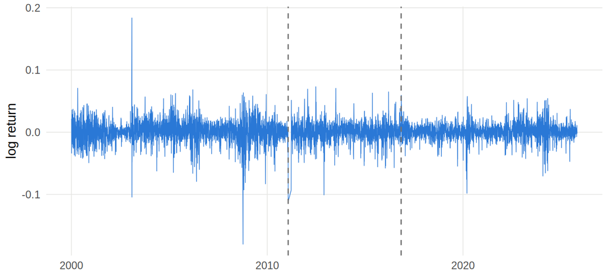

Figure 1: EGX30 daily log returns, 2000–2025. Dashed lines: 2011 closure and November 2016 float.

# 2 Validating the toolkit

Before any test is applied to EGX30 it is run on series with known dynamics: the logistic map at r = 4 (chaotic, λ = ln 2 = 0.693), the same map with measurement noise (sd 0.05), the logistic map at r = 3.5 (periodic), GARCH(1,1)-t and AR(1)-GJR-GARCH-t noise (stochastic, non-IID, not chaotic), IID Gaussian noise, and fractional Gaussian noise with H = 0.7 (long memory). All series have n = 3,000.

| series | chaotic | true_lle | true_H | bds_raw_m2 | bds_garch_m2 | archlm_p | H_AL | lw_d | tau_ami | cao_m | D2_m2 | D2_m4 | D2_m8 | K01 | nn_mse_ratio | nn_p | lle | lle_p_H0_chaos |
| --- | --- | --- | --- | --- | --- | --- | --- | --- | --- | --- | --- | --- | --- | --- | --- | --- | --- | --- |
| logistic_r4 | TRUE | 0.693 | NA | 345.301 | 344.584 | 0.000 | 0.484 | -0.014 | 7 | 2 | 0.943 | 0.993 | 1.538 | 0.998 | 0.000 | 0.000 | 0.678 | 1 |
| logistic_r4_noisy | TRUE | 0.693 | NA | 317.194 | 316.001 | 0.000 | 0.482 | -0.022 | 4 | NA | 1.926 | 2.584 | 2.180 | 0.998 | 0.115 | 0.000 | 0.281 | 1 |
| logistic_r3.5 | FALSE | NA | NA | 82089.926 | 190.942 | 0.000 | NA | NA | 2 | NA | NA | NA | NA | -0.004 | 0.000 | 0.000 | 0.260 | 1 |
| garch_t | FALSE | NA | 0.5 | 7.478 | 0.839 | 0.000 | 0.541 | 0.065 | 4 | NA | 1.996 | 3.718 | 6.260 | 0.998 | 1.081 | 1.000 | -7.519 | 0 |
| ar_gjr_garch_t | FALSE | NA | 0.5 | 14.862 | 1.276 | 0.000 | 0.529 | 0.060 | 2 | NA | 1.987 | 3.703 | 6.090 | 0.999 | 1.060 | 0.997 | -2.022 | 0 |
| iid_gaussian | FALSE | NA | 0.5 | 3.040 | 3.059 | 0.074 | 0.487 | 0.053 | 2 | NA | 1.984 | 3.751 | 6.527 | 0.998 | 1.087 | 1.000 | -3.824 | 0 |
| fgn_h0.7 | FALSE | NA | 0.7 | 8.849 | -1.931 | 0.085 | 0.612 | 0.152 | 6 | NA | 2.000 | 3.826 | 6.557 | 0.998 | 0.997 | 0.459 | -1.363 | 0 |

Column key: `bds_*` are BDS W at m = 2, ε = 1 sd, on the raw series and on GARCH(1,1) standardized residuals. `H_AL` is the Anis–Lloyd–Peters corrected Hurst exponent and `lw_d` the local-Whittle d. `tau_ami` is the AMI first-minimum delay, reported only. `cao_m` is Cao’s embedding dimension (NA means no saturation). `D2_m*` is the correlation dimension. `K01` is the 0–1 test. `nn_*` is the nearest-neighbour forecast MSE relative to the mean, with its Diebold–Mariano p-value. `lle` and `lle_p_H0_chaos` are the DChaos neural-network largest Lyapunov exponent and the p-value for H₀: λ ≥ 0.

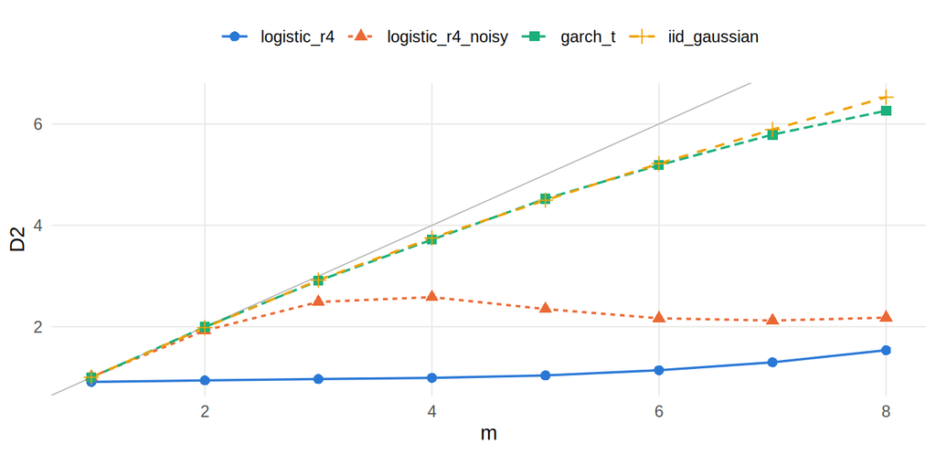

Figure 2: Correlation dimension D2 against embedding dimension m. Deterministic low-dimensional data saturate; noise tracks the diagonal.

| series | D2.1 | D2.2 | D2.3 | D2.4 | D2.5 | D2.6 | D2.7 | D2.8 |
| --- | --- | --- | --- | --- | --- | --- | --- | --- |
| logistic_r4 | 0.91 | 0.94 | 0.97 | 0.99 | 1.04 | 1.14 | 1.30 | 1.54 |
| logistic_r4_noisy | 1.01 | 1.93 | 2.49 | 2.58 | 2.35 | 2.17 | 2.12 | 2.18 |
| logistic_r3.5 | NA | NA | NA | NA | NA | NA | NA | NA |
| garch_t | 1.00 | 2.00 | 2.91 | 3.72 | 4.52 | 5.19 | 5.79 | 6.26 |
| ar_gjr_garch_t | 1.00 | 1.99 | 2.93 | 3.70 | 4.43 | 5.09 | 5.61 | 6.09 |
| iid_gaussian | 1.01 | 1.98 | 2.92 | 3.75 | 4.50 | 5.22 | 5.89 | 6.53 |
| fgn_h0.7 | 1.00 | 2.00 | 2.93 | 3.83 | 4.56 | 5.32 | 5.97 | 6.56 |

**Monte Carlo operating characteristics** (3 DGPs, 25 replications each, n = 2,000): the share of replications in which each diagnostic points to nonlinearity or chaos.

| dgp | bds_raw_reject | bds_garch_reject | zero_one_chaos | lle_chaos | nn_beats_mean |
| --- | --- | --- | --- | --- | --- |
| garch_t | 1 | 0 | 1 | 0 | 0 |
| iid_gaussian | 0 | 0 | 1 | 0 | 0 |
| logistic_noisy | 1 | 1 | 1 | 1 | 1 |

**R/S, Lo and local Whittle on IID, fGn and GARCH** (200 replications, n = 3,000): mean H, mean corrected H, Lo’s rejection rate at 5% with Andrews’ q, and mean d.

| dgp | H | H_AL | lo_reject | lw_d |
| --- | --- | --- | --- | --- |
| iid | 0.549 | 0.488 | 0.040 | -0.003 |
| fgn_0.6 | 0.632 | 0.571 | 0.280 | 0.100 |
| fgn_0.7 | 0.710 | 0.649 | 0.565 | 0.204 |
| garch_t | 0.555 | 0.494 | 0.060 | 0.001 |

**BDS on GARCH residuals needs bootstrap critical values.** On the simulated GARCH-t series (which *is* GARCH), the parametric bootstrap gives these central 95% intervals for W on the standardized residuals:

| m | eps_sd | W | p_asymptotic | p_bootstrap | cv95_lo | cv95_hi |
| --- | --- | --- | --- | --- | --- | --- |
| 2 | 0.5 | 0.851 | 0.395 | 0.37 | -1.876 | 1.875 |
| 3 | 0.5 | 0.918 | 0.359 | 0.33 | -1.521 | 1.812 |
| 4 | 0.5 | 0.559 | 0.576 | 0.54 | -1.571 | 1.591 |
| 5 | 0.5 | -0.115 | 0.908 | 0.89 | -1.375 | 1.497 |
| 2 | 1.0 | 0.789 | 0.430 | 0.38 | -1.813 | 1.586 |
| 3 | 1.0 | 1.074 | 0.283 | 0.20 | -1.699 | 1.555 |
| 4 | 1.0 | 0.800 | 0.424 | 0.24 | -1.533 | 1.437 |
| 5 | 1.0 | 0.518 | 0.604 | 0.44 | -1.289 | 1.018 |
| 2 | 1.5 | 0.907 | 0.364 | 0.29 | -1.573 | 1.573 |
| 3 | 1.5 | 1.175 | 0.240 | 0.15 | -1.392 | 1.537 |
| 4 | 1.5 | 1.174 | 0.240 | 0.12 | -1.354 | 1.358 |
| 5 | 1.5 | 1.094 | 0.274 | 0.07 | -1.129 | 1.040 |
| 2 | 2.0 | 1.045 | 0.296 | 0.25 | -1.597 | 1.737 |
| 3 | 2.0 | 1.267 | 0.205 | 0.10 | -1.317 | 1.672 |
| 4 | 2.0 | 1.541 | 0.123 | 0.03 | -1.209 | 1.323 |
| 5 | 2.0 | 1.537 | 0.124 | 0.01 | -1.047 | 1.160 |

# 3 Replication of the paper (2000–2015)

## 3.1 Descriptive statistics (Table 1)

| source | N | median | mean | sd | skewness | kurtosis | iqr | jarque_bera | jb_p | min | max |
| --- | --- | --- | --- | --- | --- | --- | --- | --- | --- | --- | --- |
| paper (1998-2015) | 4393 | 0.00064 | 0.00044 | 0.01732 | -0.35085 | 11.75502 | 0.01764 | 14120.34 | 0 | NA | NA |
| replication (2000-2015) | 3894 | 0.00109 | 0.00046 | 0.01757 | -0.37571 | 11.53357 | 0.01812 | 11906.95 | 0 | -0.17992 | 0.18369 |
| full sample (2000-2025) | 6281 | 0.00093 | 0.00055 | 0.01616 | -0.39451 | 11.49678 | 0.01610 | 19057.01 | 0 | -0.17992 | 0.18369 |

## 3.2 Unit roots (Table 2) and linear dependence (Figs 2–3)

| test | statistic | lags | cv_1pct | cv_5pct | cv_10pct |
| --- | --- | --- | --- | --- | --- |
| ADF (drift, BIC lags) | -40.525 | 1 | -3.430 | -2.860 | -2.570 |
| Phillips-Perron (Z-tau, constant, short) | -51.995 | 9 | -3.435 | -2.863 | -2.567 |

| lag | acf | pacf | band_1pct |
| --- | --- | --- | --- |
| 1 | 0.180 | 0.180 | 0.041 |
| 2 | 0.012 | -0.022 | 0.041 |
| 3 | 0.041 | 0.045 | 0.041 |
| 4 | 0.017 | 0.001 | 0.041 |
| 5 | 0.010 | 0.007 | 0.041 |
| 6 | -0.009 | -0.014 | 0.041 |
| 7 | -0.043 | -0.040 | 0.041 |
| 8 | -0.020 | -0.006 | 0.041 |
| 9 | -0.004 | 0.001 | 0.041 |
| 10 | 0.039 | 0.045 | 0.041 |
| 11 | 0.059 | 0.048 | 0.041 |
| 12 | 0.037 | 0.020 | 0.041 |
| 13 | 0.020 | 0.008 | 0.041 |
| 14 | -0.009 | -0.021 | 0.041 |
| 15 | -0.028 | -0.029 | 0.041 |

Information criteria for the AR order: AIC selects p = 10, BIC selects p = 1. The paper’s AR(2) is kept for comparability. Its residuals still fail Ljung–Box:

| lag | p_value |
| --- | --- |
| 10 | 0.0151 |
| 15 | 0.0008 |
| 20 | 0.0020 |

## 3.3 Power spectrum (Fig. 4)

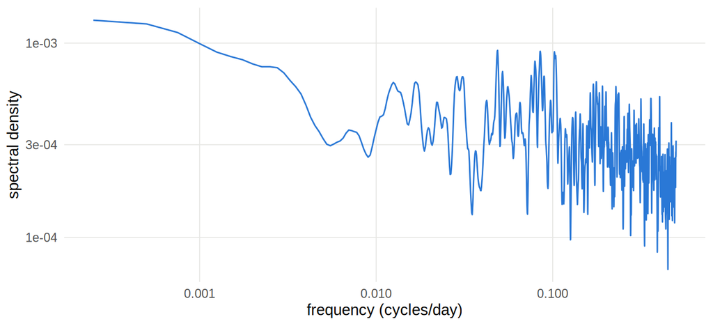

## 3.4 Variance ratios (Table 3)

The paper’s variance ratios are reproduced to two or three digits when the Lo–MacKinlay statistic is computed on the **first difference of the returns**, not on the returns themselves (referee M3):

| q | VR | paper_VR | VR_times_q |
| --- | --- | --- | --- |
| 2 | 0.6030 | 0.6082 | 1.2059 |
| 4 | 0.3001 | 0.3036 | 1.2003 |
| 8 | 0.1558 | 0.1575 | 1.2465 |
| 16 | 0.0763 | 0.0769 | 1.2208 |

## 3.5 BDS (Table 4)

The Gaussian column is the mean over 100 replications instead of a single draw.

| eps_sd | m | original | ar_filtered | shuffled | gaussian_mean |
| --- | --- | --- | --- | --- | --- |
| 0.5 | 2 | 14.156 | 12.601 | -1.098 | 0.006 |
| 0.5 | 3 | 19.796 | 18.191 | 0.721 | 0.000 |
| 0.5 | 4 | 23.837 | 22.430 | 1.450 | 0.030 |
| 0.5 | 5 | 28.958 | 27.634 | 1.714 | 0.070 |
| 1.0 | 2 | 16.260 | 14.789 | -0.519 | 0.014 |
| 1.0 | 3 | 21.611 | 20.439 | 1.126 | 0.008 |
| 1.0 | 4 | 24.983 | 24.076 | 2.018 | 0.036 |
| 1.0 | 5 | 28.053 | 27.372 | 2.374 | 0.067 |
| 1.5 | 2 | 17.442 | 16.183 | 0.111 | 0.001 |
| 1.5 | 3 | 21.949 | 21.205 | 1.373 | -0.013 |
| 1.5 | 4 | 24.478 | 24.043 | 2.249 | 0.016 |
| 1.5 | 5 | 26.403 | 26.195 | 2.535 | 0.045 |
| 2.0 | 2 | 17.722 | 17.165 | 0.433 | 0.000 |
| 2.0 | 3 | 21.156 | 21.193 | 1.302 | -0.025 |
| 2.0 | 4 | 22.893 | 23.103 | 1.964 | 0.001 |
| 2.0 | 5 | 24.103 | 24.389 | 2.063 | 0.027 |

## 3.6 Rescaled range (Tables 5–6, Figs 5–6)

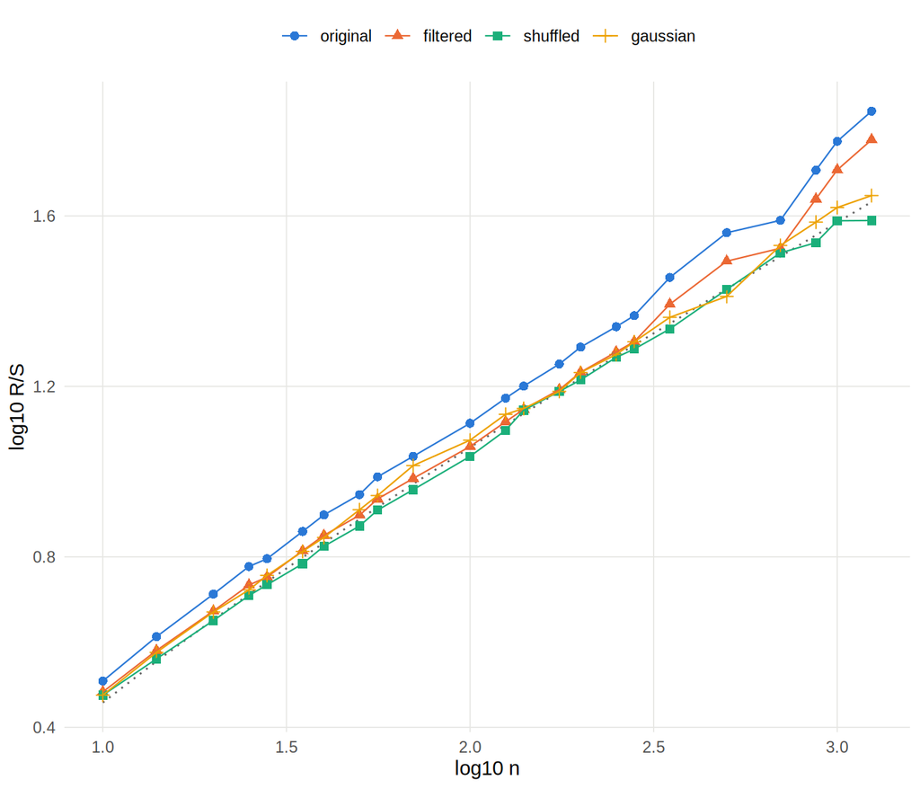

Figure 4: Classical R/S (top) and V-statistic (bottom) on the paper’s sub-period grid. The dotted line is the Anis–Lloyd–Peters expectation under IID.

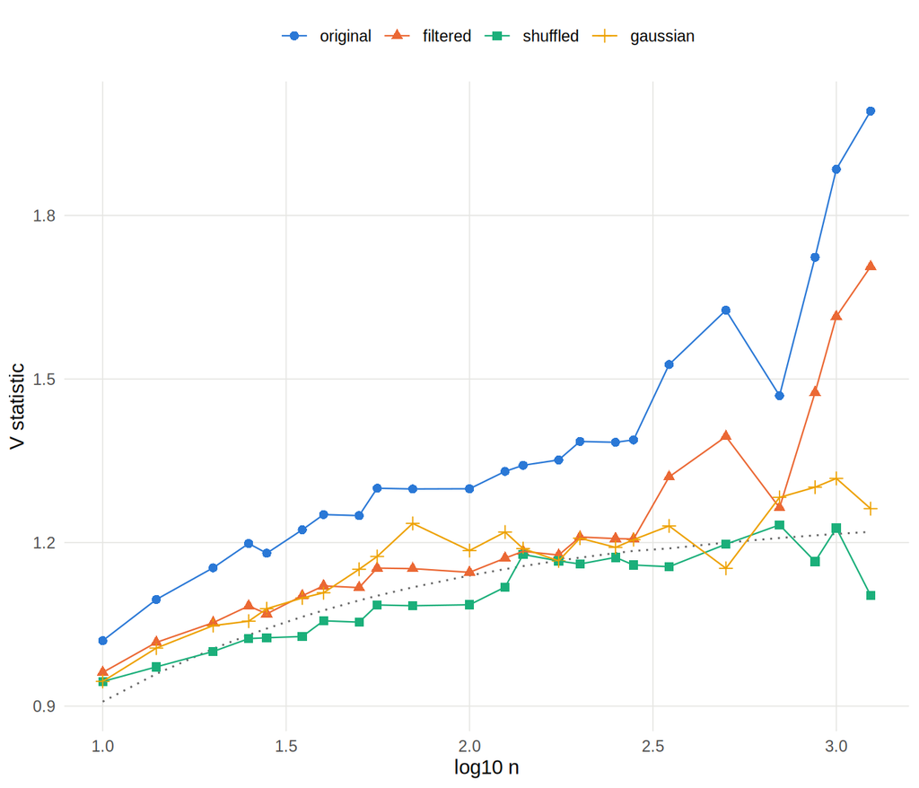

Figure 5: Classical R/S (top) and V-statistic (bottom) on the paper’s sub-period grid. The dotted line is the Anis–Lloyd–Peters expectation under IID.

| n | blocks | leftover | log_rs | v_stat | e_rs |
| --- | --- | --- | --- | --- | --- |
| 10 | 389 | 4 | 0.4831 | 0.9618 | 2.8722 |
| 14 | 278 | 2 | 0.5803 | 1.0169 | 3.5890 |
| 20 | 194 | 14 | 0.6730 | 1.0531 | 4.4958 |
| 25 | 155 | 19 | 0.7339 | 1.0838 | 5.1525 |
| 28 | 139 | 2 | 0.7527 | 1.0693 | 5.5155 |
| 35 | 111 | 9 | 0.8144 | 1.1024 | 6.2939 |
| 40 | 97 | 14 | 0.8505 | 1.1206 | 6.8034 |
| 50 | 77 | 44 | 0.8977 | 1.1174 | 7.7352 |
| 56 | 69 | 30 | 0.9360 | 1.1532 | 8.2500 |
| 70 | 55 | 44 | 0.9841 | 1.1522 | 9.3537 |
| 100 | 38 | 94 | 1.0590 | 1.1455 | 11.3960 |
| 125 | 31 | 19 | 1.1172 | 1.1714 | 12.8726 |
| 140 | 27 | 114 | 1.1464 | 1.1840 | 13.6883 |
| 175 | 22 | 44 | 1.1923 | 1.1771 | 15.4363 |
| 200 | 19 | 94 | 1.2334 | 1.2103 | 16.5798 |
| 250 | 15 | 144 | 1.2808 | 1.2073 | 18.6699 |
| 280 | 13 | 254 | 1.3051 | 1.2066 | 19.8243 |
| 350 | 11 | 44 | 1.3928 | 1.3205 | 22.2501 |
| 500 | 7 | 394 | 1.4939 | 1.3945 | 26.8327 |
| 700 | 5 | 394 | 1.5243 | 1.2639 | 31.9714 |
| 875 | 4 | 394 | 1.6399 | 1.4752 | 35.8877 |
| 1000 | 3 | 894 | 1.7081 | 1.6146 | 38.4488 |
| 1240 | 3 | 174 | 1.7787 | 1.7061 | 42.9512 |

`leftover` is the number of observations that do not fit into whole sub-periods. No n in the paper’s grid divides N (referee M5.3). The longest sub-periods rest on only three blocks.

Hurst exponents by range (Table 6, Part A). `H` is the classical estimate, `H_AL` the Anis–Lloyd–Peters corrected one:

| series | H | H_AL | k |
| --- | --- | --- | --- |
| original | 0.5985 | 0.5080 | 12 |
| original | 0.6055 | 0.5731 | 7 |
| original | 0.4473 | 0.4243 | 3 |
| original | 0.6081 | 0.5550 | 23 |
| AR(2) filtered | 0.5724 | 0.4819 | 12 |
| AR(2) filtered | 0.5883 | 0.5560 | 7 |
| AR(2) filtered | 0.4390 | 0.4160 | 3 |
| AR(2) filtered | 0.5902 | 0.5371 | 23 |

Bootstrap under IID nulls (Table 6, Part B; 2000 draws each). The p-values are one-sided for persistence (H above the null) and two-sided:

| range | null | H_obs | H_null_mean | p_upper | p_two_sided | H_AL_obs | H_AL_null_mean | p_AL_upper |
| --- | --- | --- | --- | --- | --- | --- | --- | --- |
| 1<n<125 (A-B) | shuffle | 0.5724 | 0.5717 | 0.4878 | 0.9755 | 0.4819 | 0.4811 | 0.4878 |
| 125<n<350 (B-C) | shuffle | 0.5883 | 0.5328 | 0.1664 | 0.3328 | 0.5560 | 0.5005 | 0.1664 |
| 351<n<700 (C-D as printed) | shuffle | 0.4390 | 0.5213 | 0.7641 | 0.4728 | 0.4160 | 0.4983 | 0.7641 |
| 1<n<1240 (A-D) | shuffle | 0.5902 | 0.5456 | 0.0225 | 0.0450 | 0.5371 | 0.4925 | 0.0225 |
| 1<n<125 (A-B) | gaussian | 0.5724 | 0.5731 | 0.5332 | 0.9345 | 0.4819 | 0.4825 | 0.5332 |
| 125<n<350 (B-C) | gaussian | 0.5883 | 0.5289 | 0.1524 | 0.3048 | 0.5560 | 0.4966 | 0.1524 |
| 351<n<700 (C-D as printed) | gaussian | 0.4390 | 0.5195 | 0.7271 | 0.5467 | 0.4160 | 0.4965 | 0.7271 |
| 1<n<1240 (A-D) | gaussian | 0.5902 | 0.5444 | 0.0255 | 0.0510 | 0.5371 | 0.4913 | 0.0255 |

## 3.7 Lo’s modified R/S (Table 7)

Lo’s (1991) two-sided 95% acceptance region is [0.809, 1.862]. The 99% region is [0.721, 2.098]; 0.721 is the 0.5% fractile, not a 5% critical value.

| series | q_rule | q | V | reject_95 | reject_99 |
| --- | --- | --- | --- | --- | --- |
| original | Andrews | 9 | 2.021 | TRUE | FALSE |
| original | N^(1/4) | 8 | 2.020 | TRUE | FALSE |
| original | N^(1/3) | 16 | 1.961 | TRUE | FALSE |
| original | N^(1/2) | 62 | 1.765 | FALSE | FALSE |
| original | 100 | 100 | 1.599 | FALSE | FALSE |
| original | 150 | 150 | 1.480 | FALSE | FALSE |
| AR(2) filtered | Andrews | 0 | 2.031 | TRUE | FALSE |
| AR(2) filtered | N^(1/4) | 8 | 1.991 | TRUE | FALSE |
| AR(2) filtered | N^(1/3) | 16 | 1.949 | TRUE | FALSE |
| AR(2) filtered | N^(1/2) | 62 | 1.764 | FALSE | FALSE |
| AR(2) filtered | 100 | 100 | 1.599 | FALSE | FALSE |
| AR(2) filtered | 150 | 150 | 1.481 | FALSE | FALSE |

# 4 Referee revisions

Each block reports the paper window (2000–2015) and the full sample (2000–2025).

## 4.1 Variance ratios on the correct series (M3)

```
**paper**


|  q|    VR|     z1|    z2| p_z2|
|--:|-----:|------:|-----:|----:|
|  2| 1.181| 11.275| 5.457|    0|
|  4| 1.304| 10.132| 5.371|    0|
|  8| 1.397|  8.370| 4.967|    0|
| 16| 1.475|  6.729| 4.423|    0|


|    CD1|   CD2| cv_5pct|
|------:|-----:|-------:|
| 11.237| 5.439|   2.491|


|test               |  p|
|:------------------|--:|
|Lo-MacKinlay q=2   |  0|
|Lo-MacKinlay q=4   |  0|
|Lo-MacKinlay q=8   |  0|
|Lo-MacKinlay q=16  |  0|
|Chow-Denning joint |  0|

**full**


|  q|    VR|     z1|    z2| p_z2|
|--:|-----:|------:|-----:|----:|
|  2| 1.174| 13.784| 6.678|    0|
|  4| 1.301| 12.751| 6.714|    0|
|  8| 1.390| 10.446| 6.063|    0|
| 16| 1.467|  8.411| 5.362|    0|


|    CD1|   CD2| cv_5pct|
|------:|-----:|-------:|
| 13.754| 6.687|   2.491|


|test               |  p|
|:------------------|--:|
|Lo-MacKinlay q=2   |  0|
|Lo-MacKinlay q=4   |  0|
|Lo-MacKinlay q=8   |  0|
|Lo-MacKinlay q=16  |  0|
|Chow-Denning joint |  0|
```

## 4.2 Conditional heteroskedasticity and BDS (M2)

| sample | model | loglik | aic | bic | persistence | leverage | leverage_t |
| --- | --- | --- | --- | --- | --- | --- | --- |
| 2000-2015 | GARCH | 10852.64 | -5.5704 | -5.5592 | 0.9766 | NA | NA |
| 2000-2015 | GJR | 10862.07 | -5.5748 | -5.5619 | 0.9670 | 0.0971 | 3.8495 |
| 2000-2015 | EGARCH | 10869.30 | -5.5785 | -5.5656 | 0.9500 | 0.2927 | 9.7725 |
| 2000-2025 | GARCH | 18109.91 | -5.7643 | -5.7568 | 0.9800 | NA | NA |
| 2000-2025 | GJR | 18120.61 | -5.7674 | -5.7588 | 0.9760 | 0.0767 | 0.1513 |
| 2000-2025 | EGARCH | 18129.46 | -5.7702 | -5.7617 | 0.9596 | 0.2782 | 12.3424 |

ARCH-LM before and after filtering:

| sample | series | lags | LM | p |
| --- | --- | --- | --- | --- |
| 2000-2015 | AR(2) residuals | 5 | 388.7927 | 0.0000 |
| 2000-2015 | AR(2) residuals | 10 | 405.3655 | 0.0000 |
| 2000-2015 | AR(2)-GJR-t std. residuals | 5 | 14.0209 | 0.0155 |
| 2000-2015 | AR(2)-GJR-t std. residuals | 10 | 20.6734 | 0.0235 |
| 2000-2015 | AR(2)-EGARCH-t std. residuals | 5 | 43.5159 | 0.0000 |
| 2000-2015 | AR(2)-EGARCH-t std. residuals | 10 | 48.3473 | 0.0000 |
| 2000-2025 | AR(2) residuals | 5 | 646.3482 | 0.0000 |
| 2000-2025 | AR(2) residuals | 10 | 680.2456 | 0.0000 |
| 2000-2025 | AR(2)-GJR-t std. residuals | 5 | 13.8313 | 0.0167 |
| 2000-2025 | AR(2)-GJR-t std. residuals | 10 | 22.9804 | 0.0108 |
| 2000-2025 | AR(2)-EGARCH-t std. residuals | 5 | 48.0852 | 0.0000 |
| 2000-2025 | AR(2)-EGARCH-t std. residuals | 10 | 54.4539 | 0.0000 |

BDS on GARCH-standardized residuals, with asymptotic p-values:

| sample | filter | m | eps_sd | W | p |
| --- | --- | --- | --- | --- | --- |
| 2000-2015 | AR(2)-GJR-t | 2 | 0.5 | 0.096 | 0.923 |
| 2000-2015 | AR(2)-GJR-t | 3 | 0.5 | 0.506 | 0.613 |
| 2000-2015 | AR(2)-GJR-t | 4 | 0.5 | 0.373 | 0.709 |
| 2000-2015 | AR(2)-GJR-t | 5 | 0.5 | 0.345 | 0.730 |
| 2000-2015 | AR(2)-GJR-t | 2 | 1.0 | 0.391 | 0.696 |
| 2000-2015 | AR(2)-GJR-t | 3 | 1.0 | 0.804 | 0.422 |
| 2000-2015 | AR(2)-GJR-t | 4 | 1.0 | 0.894 | 0.371 |
| 2000-2015 | AR(2)-GJR-t | 5 | 1.0 | 1.073 | 0.283 |
| 2000-2015 | AR(2)-GJR-t | 2 | 1.5 | 0.998 | 0.318 |
| 2000-2015 | AR(2)-GJR-t | 3 | 1.5 | 1.231 | 0.218 |
| 2000-2015 | AR(2)-GJR-t | 4 | 1.5 | 1.199 | 0.230 |
| 2000-2015 | AR(2)-GJR-t | 5 | 1.5 | 1.180 | 0.238 |
| 2000-2015 | AR(2)-GJR-t | 2 | 2.0 | 1.819 | 0.069 |
| 2000-2015 | AR(2)-GJR-t | 3 | 2.0 | 1.716 | 0.086 |
| 2000-2015 | AR(2)-GJR-t | 4 | 2.0 | 1.527 | 0.127 |
| 2000-2015 | AR(2)-GJR-t | 5 | 2.0 | 1.299 | 0.194 |
| 2000-2015 | AR(2)-EGARCH-t | 2 | 0.5 | -0.116 | 0.907 |
| 2000-2015 | AR(2)-EGARCH-t | 3 | 0.5 | 0.265 | 0.791 |
| 2000-2015 | AR(2)-EGARCH-t | 4 | 0.5 | 0.155 | 0.877 |
| 2000-2015 | AR(2)-EGARCH-t | 5 | 0.5 | 0.150 | 0.881 |
| 2000-2015 | AR(2)-EGARCH-t | 2 | 1.0 | 0.182 | 0.855 |
| 2000-2015 | AR(2)-EGARCH-t | 3 | 1.0 | 0.541 | 0.589 |
| 2000-2015 | AR(2)-EGARCH-t | 4 | 1.0 | 0.517 | 0.605 |
| 2000-2015 | AR(2)-EGARCH-t | 5 | 1.0 | 0.567 | 0.570 |
| 2000-2015 | AR(2)-EGARCH-t | 2 | 1.5 | 1.132 | 0.257 |
| 2000-2015 | AR(2)-EGARCH-t | 3 | 1.5 | 1.345 | 0.179 |
| 2000-2015 | AR(2)-EGARCH-t | 4 | 1.5 | 1.245 | 0.213 |
| 2000-2015 | AR(2)-EGARCH-t | 5 | 1.5 | 1.192 | 0.233 |
| 2000-2015 | AR(2)-EGARCH-t | 2 | 2.0 | 2.479 | 0.013 |
| 2000-2015 | AR(2)-EGARCH-t | 3 | 2.0 | 2.382 | 0.017 |
| 2000-2015 | AR(2)-EGARCH-t | 4 | 2.0 | 2.138 | 0.033 |
| 2000-2015 | AR(2)-EGARCH-t | 5 | 2.0 | 1.918 | 0.055 |
| 2000-2025 | AR(2)-GJR-t | 2 | 0.5 | 0.026 | 0.979 |
| 2000-2025 | AR(2)-GJR-t | 3 | 0.5 | 0.692 | 0.489 |
| 2000-2025 | AR(2)-GJR-t | 4 | 0.5 | 1.081 | 0.280 |
| 2000-2025 | AR(2)-GJR-t | 5 | 0.5 | 1.088 | 0.277 |
| 2000-2025 | AR(2)-GJR-t | 2 | 1.0 | 0.500 | 0.617 |
| 2000-2025 | AR(2)-GJR-t | 3 | 1.0 | 1.176 | 0.239 |
| 2000-2025 | AR(2)-GJR-t | 4 | 1.0 | 1.638 | 0.102 |
| 2000-2025 | AR(2)-GJR-t | 5 | 1.0 | 1.813 | 0.070 |
| 2000-2025 | AR(2)-GJR-t | 2 | 1.5 | 1.448 | 0.148 |
| 2000-2025 | AR(2)-GJR-t | 3 | 1.5 | 1.903 | 0.057 |
| 2000-2025 | AR(2)-GJR-t | 4 | 1.5 | 2.220 | 0.026 |
| 2000-2025 | AR(2)-GJR-t | 5 | 1.5 | 2.226 | 0.026 |
| 2000-2025 | AR(2)-GJR-t | 2 | 2.0 | 2.259 | 0.024 |
| 2000-2025 | AR(2)-GJR-t | 3 | 2.0 | 2.287 | 0.022 |
| 2000-2025 | AR(2)-GJR-t | 4 | 2.0 | 2.407 | 0.016 |
| 2000-2025 | AR(2)-GJR-t | 5 | 2.0 | 2.228 | 0.026 |
| 2000-2025 | AR(2)-EGARCH-t | 2 | 0.5 | -0.153 | 0.878 |
| 2000-2025 | AR(2)-EGARCH-t | 3 | 0.5 | 0.446 | 0.655 |
| 2000-2025 | AR(2)-EGARCH-t | 4 | 0.5 | 0.703 | 0.482 |
| 2000-2025 | AR(2)-EGARCH-t | 5 | 0.5 | 0.462 | 0.644 |
| 2000-2025 | AR(2)-EGARCH-t | 2 | 1.0 | 0.284 | 0.777 |
| 2000-2025 | AR(2)-EGARCH-t | 3 | 1.0 | 0.915 | 0.360 |
| 2000-2025 | AR(2)-EGARCH-t | 4 | 1.0 | 1.270 | 0.204 |
| 2000-2025 | AR(2)-EGARCH-t | 5 | 1.0 | 1.294 | 0.196 |
| 2000-2025 | AR(2)-EGARCH-t | 2 | 1.5 | 1.659 | 0.097 |
| 2000-2025 | AR(2)-EGARCH-t | 3 | 1.5 | 2.130 | 0.033 |
| 2000-2025 | AR(2)-EGARCH-t | 4 | 1.5 | 2.437 | 0.015 |
| 2000-2025 | AR(2)-EGARCH-t | 5 | 1.5 | 2.416 | 0.016 |
| 2000-2025 | AR(2)-EGARCH-t | 2 | 2.0 | 3.055 | 0.002 |
| 2000-2025 | AR(2)-EGARCH-t | 3 | 2.0 | 3.173 | 0.002 |
| 2000-2025 | AR(2)-EGARCH-t | 4 | 2.0 | 3.340 | 0.001 |
| 2000-2025 | AR(2)-EGARCH-t | 5 | 2.0 | 3.211 | 0.001 |

BDS on AR(2)-GJR-t residuals with parametric-bootstrap p-values and 95% bands (199 and 199 successful refits):

| sample | m | eps_sd | W | p_asymptotic | p_bootstrap | cv95_lo | cv95_hi |
| --- | --- | --- | --- | --- | --- | --- | --- |
| 2000-2015 | 2 | 0.5 | 0.096 | 0.923 | 0.900 | -1.627 | 1.622 |
| 2000-2015 | 3 | 0.5 | 0.506 | 0.613 | 0.495 | -1.593 | 1.597 |
| 2000-2015 | 4 | 0.5 | 0.373 | 0.709 | 0.590 | -1.305 | 1.391 |
| 2000-2015 | 5 | 0.5 | 0.345 | 0.730 | 0.630 | -1.244 | 1.284 |
| 2000-2015 | 2 | 1.0 | 0.391 | 0.696 | 0.625 | -1.653 | 1.684 |
| 2000-2015 | 3 | 1.0 | 0.804 | 0.422 | 0.235 | -1.338 | 1.671 |
| 2000-2015 | 4 | 1.0 | 0.894 | 0.371 | 0.135 | -1.057 | 1.188 |
| 2000-2015 | 5 | 1.0 | 1.073 | 0.283 | 0.040 | -0.954 | 0.989 |
| 2000-2015 | 2 | 1.5 | 0.998 | 0.318 | 0.260 | -1.572 | 1.624 |
| 2000-2015 | 3 | 1.5 | 1.231 | 0.218 | 0.075 | -1.213 | 1.481 |
| 2000-2015 | 4 | 1.5 | 1.199 | 0.230 | 0.035 | -0.944 | 1.008 |
| 2000-2015 | 5 | 1.5 | 1.180 | 0.238 | 0.015 | -0.779 | 0.961 |
| 2000-2015 | 2 | 2.0 | 1.819 | 0.069 | 0.035 | -1.556 | 1.740 |
| 2000-2015 | 3 | 2.0 | 1.716 | 0.086 | 0.015 | -1.198 | 1.321 |
| 2000-2015 | 4 | 2.0 | 1.527 | 0.127 | 0.010 | -1.056 | 1.021 |
| 2000-2015 | 5 | 2.0 | 1.299 | 0.194 | 0.010 | -0.838 | 1.012 |
| 2000-2025 | 2 | 0.5 | 0.026 | 0.979 | 0.980 | -1.687 | 1.815 |
| 2000-2025 | 3 | 0.5 | 0.692 | 0.489 | 0.360 | -1.205 | 1.929 |
| 2000-2025 | 4 | 0.5 | 1.081 | 0.280 | 0.110 | -1.081 | 1.485 |
| 2000-2025 | 5 | 0.5 | 1.088 | 0.277 | 0.125 | -1.118 | 1.414 |
| 2000-2025 | 2 | 1.0 | 0.500 | 0.617 | 0.545 | -1.684 | 1.667 |
| 2000-2025 | 3 | 1.0 | 1.176 | 0.239 | 0.130 | -1.206 | 1.873 |
| 2000-2025 | 4 | 1.0 | 1.638 | 0.102 | 0.015 | -0.997 | 1.288 |
| 2000-2025 | 5 | 1.0 | 1.813 | 0.070 | 0.005 | -1.043 | 1.169 |
| 2000-2025 | 2 | 1.5 | 1.448 | 0.148 | 0.100 | -1.628 | 1.547 |
| 2000-2025 | 3 | 1.5 | 1.903 | 0.057 | 0.015 | -1.255 | 1.565 |
| 2000-2025 | 4 | 1.5 | 2.220 | 0.026 | 0.005 | -1.104 | 1.339 |
| 2000-2025 | 5 | 1.5 | 2.226 | 0.026 | 0.005 | -1.017 | 1.035 |
| 2000-2025 | 2 | 2.0 | 2.259 | 0.024 | 0.015 | -1.773 | 1.508 |
| 2000-2025 | 3 | 2.0 | 2.287 | 0.022 | 0.005 | -1.513 | 1.518 |
| 2000-2025 | 4 | 2.0 | 2.407 | 0.016 | 0.005 | -1.178 | 1.280 |
| 2000-2025 | 5 | 2.0 | 2.228 | 0.026 | 0.005 | -1.105 | 1.130 |

## 4.3 Long memory (M4–M6)

| sample | series | H_rs | H_rs_AL | dfa_alpha | gph_d | gph_se | lw_d | lw_se | lo_V_andrews |
| --- | --- | --- | --- | --- | --- | --- | --- | --- | --- |
| 2000-2015 | AR(2) residuals | 0.578 | 0.520 | 0.553 | 0.204 | 0.045 | 0.071 | 0.034 | 2.031 |
| 2000-2015 | \|GJR std. residuals\| | 0.594 | 0.536 | 0.584 | 0.282 | 0.045 | 0.028 | 0.034 | 1.657 |
| 2000-2025 | AR(2) residuals | 0.604 | 0.551 | 0.579 | 0.159 | 0.040 | 0.088 | 0.029 | 1.647 |
| 2000-2025 | \|GJR std. residuals\| | 0.580 | 0.527 | 0.562 | 0.278 | 0.040 | 0.018 | 0.029 | 2.033 |

| sample | q_rule | q | V | reject_95 | reject_99 |
| --- | --- | --- | --- | --- | --- |
| 2000-2015 | Andrews | 0 | 2.031 | TRUE | FALSE |
| 2000-2015 | N^(1/4) | 8 | 1.991 | TRUE | FALSE |
| 2000-2015 | N^(1/3) | 16 | 1.949 | TRUE | FALSE |
| 2000-2015 | N^(1/2) | 62 | 1.764 | FALSE | FALSE |
| 2000-2015 | 100 | 100 | 1.599 | FALSE | FALSE |
| 2000-2015 | 150 | 150 | 1.481 | FALSE | FALSE |
| 2000-2025 | Andrews | 0 | 1.647 | FALSE | FALSE |
| 2000-2025 | N^(1/4) | 9 | 1.623 | FALSE | FALSE |
| 2000-2025 | N^(1/3) | 18 | 1.580 | FALSE | FALSE |
| 2000-2025 | N^(1/2) | 79 | 1.397 | FALSE | FALSE |
| 2000-2025 | 100 | 100 | 1.338 | FALSE | FALSE |
| 2000-2025 | 150 | 150 | 1.256 | FALSE | FALSE |

## 4.4 Chaos-specific diagnostics (M1)

| series | tau_ami | cao_m | D2_m2 | D2_m4 | D2_m8 | K01 | nn_mse_ratio | nn_p | lle | lle_se | lle_p_H0_chaos | lle_m | lle_m_max |
| --- | --- | --- | --- | --- | --- | --- | --- | --- | --- | --- | --- | --- | --- |
| 2000-2015 AR(2) resid. | 6 | NA | 1.983 | 3.637 | 5.267 | 0.998 | 1.076 | 0.996 | -0.599 | 0.048 | 0 | 3 | 4 |
| 2000-2015 GJR std. resid. | 2 | NA | 1.995 | 3.757 | 6.210 | 0.998 | 1.072 | 1.000 | -0.624 | 0.046 | 0 | 3 | 3 |
| 2000-2025 AR(2) resid. | 6 | NA | 1.980 | 3.636 | 5.273 | 0.998 | 1.102 | 1.000 | -2.839 | 0.152 | 0 | 2 | 4 |
| 2000-2025 GJR std. resid. | 4 | NA | 2.001 | 3.762 | 6.234 | 0.998 | 1.112 | 1.000 | -0.823 | 0.020 | 0 | 3 | 4 |

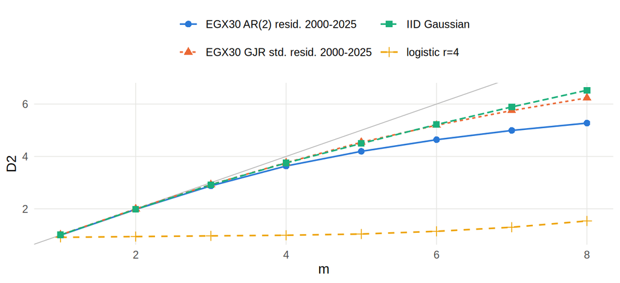

Figure 6: Correlation dimension of EGX30 filtered returns against m, with the logistic map for reference.

## 4.5 Structural breaks and regimes (M7–M8)

Bai–Perron (strucchange, weekly returns, BIC). Mean breaks: 2003-03-19, 2006-01-29. Volatility breaks: 2008-08-07, 2009-11-18. The sup-F test for a single mean break has p = 0.045.

E-divisive (ecp, weekly returns) distributional change points: 2003-03-19, 2008-05-06, 2009-02-08.

PELT variance regimes (changepoint, daily, MBIC):

| start | end | n | mean | sd_annual |
| --- | --- | --- | --- | --- |
| 2000-01-03 | 2001-04-19 | 318 | -0.0020 | 0.3188 |
| 2001-04-22 | 2002-04-14 | 245 | -0.0012 | 0.2166 |
| 2002-04-15 | 2003-01-05 | 180 | 0.0003 | 0.1028 |
| 2003-01-06 | 2003-04-07 | 60 | 0.0032 | 0.5510 |
| 2003-04-08 | 2006-01-05 | 684 | 0.0035 | 0.2469 |
| 2006-01-08 | 2006-08-01 | 138 | -0.0010 | 0.4103 |
| 2006-08-02 | 2008-08-07 | 495 | 0.0009 | 0.1906 |
| 2008-08-10 | 2008-12-01 | 77 | -0.0103 | 0.6238 |
| 2008-12-02 | 2010-07-12 | 398 | 0.0010 | 0.3081 |
| 2010-07-13 | 2011-01-16 | 126 | 0.0013 | 0.1270 |
| 2011-01-17 | 2012-12-16 | 431 | -0.0007 | 0.3039 |
| 2012-12-17 | 2017-03-05 | 1031 | 0.0008 | 0.2285 |
| 2017-03-06 | 2020-02-27 | 726 | 0.0001 | 0.1593 |
| 2020-03-01 | 2020-06-07 | 63 | -0.0025 | 0.4532 |
| 2020-06-08 | 2022-02-17 | 417 | 0.0001 | 0.1404 |
| 2022-02-20 | 2024-01-24 | 469 | 0.0019 | 0.2314 |
| 2024-01-28 | 2024-05-19 | 74 | -0.0002 | 0.4531 |
| 2024-05-20 | 2025-10-30 | 349 | 0.0010 | 0.1534 |

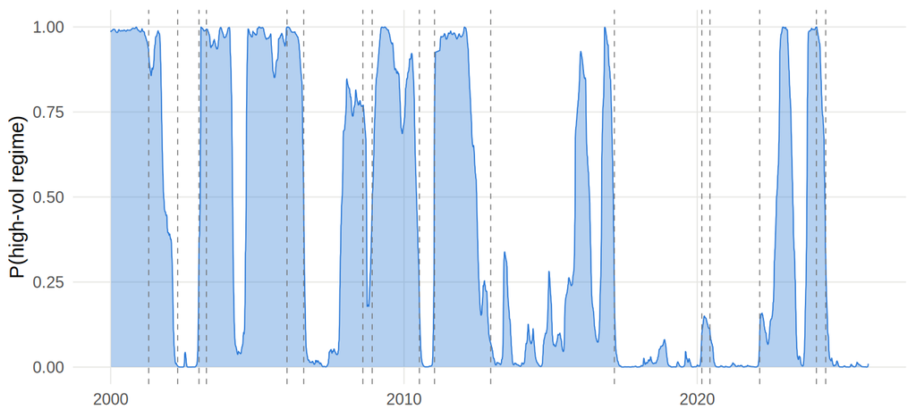

Figure 7: MS-GJR-t smoothed probability of the high-volatility regime, with PELT variance breaks (vertical ticks).

MSGARCH: single- vs two-regime GJR-t (percentage returns):

| model | loglik | aic | bic |
| --- | --- | --- | --- |
| 1-regime GJR-t | -10895.84 | 21801.68 | 21835.41 |
| 2-regime MS-GJR-t | -10861.32 | 21746.65 | 21827.59 |

| regime | daily_uncond_vol_pct |
| --- | --- |
| 1 | 1.136 |
| 2 | 1.979 |

| t+1\|k=1 | t+1\|k=2 |
| --- | --- |
| 0.9961 | 0.0039 |
| 0.0053 | 0.9947 |

TV-GARCH (tvgarch): the variance-constancy test selects 1 transition location(s). BDS on AR(2)-TV-GARCH standardized residuals:

| m | eps_sd | W | p |
| --- | --- | --- | --- |
| 2 | 0.5 | 0.501 | 0.616 |
| 3 | 0.5 | 1.417 | 0.156 |
| 4 | 0.5 | 1.883 | 0.060 |
| 5 | 0.5 | 1.852 | 0.064 |
| 2 | 1.0 | 0.995 | 0.320 |
| 3 | 1.0 | 1.849 | 0.064 |
| 4 | 1.0 | 2.332 | 0.020 |
| 5 | 1.0 | 2.458 | 0.014 |
| 2 | 1.5 | 2.031 | 0.042 |
| 3 | 1.5 | 2.681 | 0.007 |
| 4 | 1.5 | 3.068 | 0.002 |
| 5 | 1.5 | 3.058 | 0.002 |
| 2 | 2.0 | 2.825 | 0.005 |
| 3 | 2.0 | 3.006 | 0.003 |
| 4 | 2.0 | 3.210 | 0.001 |
| 5 | 2.0 | 3.037 | 0.002 |

## 4.6 Subsamples

Diagnostics by period, on AR(2)-GJR-t standardized residuals unless stated.

| subsample | N | bds_raw_m2_1sd | bds_gjr_max_abs_W | bds_gjr_min_p | H_AL | lw_d | lo_V | K01 | lle | lle_p_H0_chaos |
| --- | --- | --- | --- | --- | --- | --- | --- | --- | --- | --- |
| paper window (2000-2015) | 3894 | 16.260 | 1.819 | 0.069 | 0.520 | 0.071 | 2.031 | 0.998 | -0.620 | 0 |
| pre-float (2000-Oct 2016) | 4099 | 16.245 | 1.480 | 0.139 | 0.518 | 0.062 | 1.960 | 0.998 | -23.499 | 0 |
| post-float (Nov 2016-2025) | 2182 | 11.025 | 2.137 | 0.033 | 0.532 | 0.070 | 1.982 | 0.998 | -5.090 | 0 |
| full sample | 6281 | 20.565 | 2.407 | 0.016 | 0.551 | 0.088 | 1.647 | 0.998 | -0.823 | 0 |

Dropping the 2011 closure-spanning return: N = 6280, max |W| = 2.45, min p = 0.014.

## 4.7 Backfilled index values

CASE 30 was launched on 2 February 2003 to replace CASE 50. It “was retroactively calculated for five years as of 1/1/1998” (CBE Annual Report 2002/2003, p. 87). Every value before the launch, including the paper’s first years, is therefore a reconstruction from the 30 stocks that were most liquid in 2003, not a published index. The table repeats the main diagnostics on the backfilled and live segments. `near_zero_pct` is the share of days with |r| < 0.01%, a proxy for thin trading. Annualised figures use 245 days.

| segment | N | mean_ann_pct | sd_ann_pct | skewness | kurtosis | near_zero_pct | acf1 | ljung_box20_p | VR2 | VR2_z2 | bds_raw_maxW | bds_gjr_max_absW | bds_gjr_min_p | gjr_persistence | H_AL | lw_d | lw_se | lo_V | lle | lle_p_H0_chaos |
| --- | --- | --- | --- | --- | --- | --- | --- | --- | --- | --- | --- | --- | --- | --- | --- | --- | --- | --- | --- | --- |
| backfilled (2000 - Jan 2003) | 761 | -23.312 | 25.336 | 0.375 | 4.704 | 1.183 | 0.197 | 0.326 | 1.180 | 3.877 | 40.357 | 2.643 | 0.008 | 0.999 | 0.492 | -0.007 | 0.058 | 1.341 | -10.262 | 0 |
| live, paper window (Feb 2003 - 2015) | 3133 | 19.552 | 27.983 | -0.521 | 12.665 | 0.638 | 0.159 | 0.001 | 1.143 | 4.052 | 22.404 | 2.065 | 0.039 | 0.931 | 0.517 | 0.067 | 0.037 | 1.879 | -2.769 | 0 |
| live, full (Feb 2003 - 2025) | 5520 | 18.633 | 25.270 | -0.502 | 12.509 | 0.779 | 0.158 | 0.000 | 1.147 | 5.472 | 30.153 | 2.573 | 0.010 | 0.963 | 0.539 | 0.070 | 0.030 | 2.093 | -3.199 | 0 |
| paper window (2000 - 2015) | 3894 | 11.175 | 27.504 | -0.376 | 11.534 | 0.745 | 0.180 | 0.002 | 1.181 | 5.457 | 28.958 | 1.819 | 0.069 | 0.967 | 0.520 | 0.071 | 0.034 | 2.031 | -0.620 | 0 |

Formal tests of a change at the launch date:

| test | statistic | p_value |
| --- | --- | --- |
| Chow test, AR(1) coefficients at 2 Feb 2003 (paper window) | 2.3911 | 0.0917 |
| Lag-1 autocorrelation equal (Fisher z), backfilled vs live 2003-2015 | 0.9714 | 0.3314 |
| Variance equal (F test), backfilled vs live 2003-2015 | 0.8197 | 0.0007 |

# 5 Reproducibility

- Pipeline: `targets` (`_targets.R`), with functions in `R/`. Packages are pinned in `renv.lock`, and `report.qmd` is rendered by `tar_quarto()`.
- Seeds are fixed in `tar_option_set(seed = ...)` and in each bootstrap.
- Critical values: Lo (1991) Table II. BDS uses ε in units of the series sd.
- Key settings: DChaos uses the QR (`SLE`) method with bootstrap blocking, m ∈ 1–4, h ∈ 2–10, and B = 500. BDS parametric bootstrap uses B = 199. The Hurst bootstrap uses B = 2,000.

| package | version |
| --- | --- |
| targets | 1.12.0 |
| tarchetypes | 0.14.1 |
| tseries | 0.10.63 |
| urca | 1.3.4 |
| vrtest | 1.2 |
| rugarch | 1.5.6 |
| FinTS | 0.4.9 |
| nonlinearTseries | 0.3.2 |
| DChaos | 0.1.7 |
| strucchange | 1.6.0 |
| changepoint | 2.3 |
| ecp | 3.1.6 |
| MSGARCH | 2.51 |
| tvgarch | 2.4.3 |